# Part I - (Dataset Exploration Title)

### What features in the dataset do you think will help support your investigation into your feature(s) of interest?

1) For the first point of interest creating new separate date, time & day column will be beneficial.  
2) Plotting mean of `duration_sec` will help answer the second point  
3) bivariate & multivariate plots would be essential in finding out any hidden patterns.

```python
# converting `start_time' & `end_time' column object to datetime format
df.start_time = pd.to_datetime(df.start_time)

df.end_time = pd.to_datetime(df.end_time)
```

```python
df.start_time.info()
```

```
<class 'pandas.core.series.Series'>
RangeIndex: 183412 entries, 0 to 183411
Series name: start_time
Non-Null Count   Dtype
--------------   -----
183412 non-null  datetime64[ns]
dtypes: datetime64[ns](1)
memory usage: 1.4 MB
```

```python
pd.set_option('display.max_columns', None)
pd.set_option('display.max_rows', None)
```

```python
# creating separate date, hour columns for start & end time
df["start_date"] = df.start_time.dt.date
df["start_hour"] = df.start_time.dt.hour

df["end_date"] = df.end_time.dt.date
df["end_hour"] = df.end_time.dt.hour
```

```python
# creating day of week column
df['start_day_of_week'] = df['start_time'].dt.day_name()

df['end_day_of_week'] = df['end_time'].dt.day_name()
```

```python
len(df.start_station_id.unique())
```

```
330
```

```python
# converting 'start_station_id' & 'end_station_id' from float to object
df[["start_station_id", "end_station_id"]] = df[["start_station_id", "end_station_id"]].astype('object')
```

```python
# converting 'bike_id' from float to object
df["bike_id"] = df.bike_id.astype(object)
```

```python
# checking for null values in columns 'member_birth_year'
df[df.member_birth_year.isna() == True].head(100)
```

[output not shown]

[output cut: 70 more lines]

Yes, there are null values in 'member_birth_year'

```python
df.member_birth_year.isnull().sum()
```

```
8265
```

```python
df.member_gender.isnull().sum()
```

```
8265
```

```python
df.info()
```

```
<class 'pandas.core.frame.DataFrame'>
RangeIndex: 183412 entries, 0 to 183411
Data columns (total 22 columns):
 #   Column                   Non-Null Count   Dtype
---  ------                   --------------   -----
 0   duration_sec             183412 non-null  int64
 1   start_time               183412 non-null  datetime64[ns]
 2   end_time                 183412 non-null  datetime64[ns]
 3   start_station_id         183215 non-null  object
 4   start_station_name       183215 non-null  object
 5   start_station_latitude   183412 non-null  float64
 6   start_station_longitude  183412 non-null  float64
 7   end_station_id           183215 non-null  object
 8   end_station_name         183215 non-null  object
 9   end_station_latitude     183412 non-null  float64
 10  end_station_longitude    183412 non-null  float64
 11  bike_id                  183412 non-null  object
 12  user_type                183412 non-null  object
 13  member_birth_year        175147 non-null  float64
 14  member_gender            175147 non-null  object
 15  bike_share_for_all_trip  183412 non-null  object
 16  start_date               183412 non-null  object
 17  start_hour               183412 non-null  int64
 18  end_date                 183412 non-null  object
 19  end_hour                 183412 non-null  int64
 20  start_day_of_week        183412 non-null  object
 21  end_day_of_week          183412 non-null  object
dtypes: datetime64[ns](2), float64(5), int64(3), object(12)
memory usage: 30.8+ MB
```

```python
df[df.start_station_id.isnull() == True]
```

[output not shown]

[output cut: 167 more lines]

```python
df.isnull().sum()
```

```
duration_sec                  0
start_time                    0
end_time                      0
start_station_id            197
start_station_name          197
start_station_latitude        0
start_station_longitude       0
end_station_id              197
end_station_name            197
end_station_latitude          0
end_station_longitude         0
bike_id                       0
user_type                     0
member_birth_year          8265
member_gender              8265
bike_share_for_all_trip       0
start_date                    0
start_hour                    0
end_date                      0
end_hour                      0
start_day_of_week             0
end_day_of_week               0
dtype: int64
```

```python
# dropping all 197 null values associated with station_id and creating new dataframe 'df_clean'
df_clean = df.drop(df.index[df.start_station_id.isnull() == True])
```

```python
df_clean[df_clean.start_station_id.isnull() == True]
```

|  | duration_sec | start_time | end_time | start_station_id | start_station_name | start_station_latitude | start_station_longitude | end_station_id | end_station_name | end_station_latitude | end_station_longitude | bike_id | user_type | member_birth_year | member_gender | bike_share_for_all_trip | start_date | start_hour | end_date | end_hour | start_day_of_week | end_day_of_week |
| --- | --- | --- | --- | --- | --- | --- | --- | --- | --- | --- | --- | --- | --- | --- | --- | --- | --- | --- | --- | --- | --- | --- |

```python
# dropping all 8265 null values associated with station_id
df_clean.drop(df_clean.index[df_clean.member_gender.isnull() == True], inplace=True)
```

```python
df_clean[df_clean.member_gender.isnull() == True]
```

|  | duration_sec | start_time | end_time | start_station_id | start_station_name | start_station_latitude | start_station_longitude | end_station_id | end_station_name | end_station_latitude | end_station_longitude | bike_id | user_type | member_birth_year | member_gender | bike_share_for_all_trip | start_date | start_hour | end_date | end_hour | start_day_of_week | end_day_of_week |
| --- | --- | --- | --- | --- | --- | --- | --- | --- | --- | --- | --- | --- | --- | --- | --- | --- | --- | --- | --- | --- | --- | --- |

```python
df_clean.shape
```

```
(174952, 22)
```

```python
df_clean.isnull().sum()
```

```
duration_sec               0
start_time                 0
end_time                   0
start_station_id           0
start_station_name         0
start_station_latitude     0
start_station_longitude    0
end_station_id             0
end_station_name           0
end_station_latitude       0
end_station_longitude      0
bike_id                    0
user_type                  0
member_birth_year          0
member_gender              0
bike_share_for_all_trip    0
start_date                 0
start_hour                 0
end_date                   0
end_hour                   0
start_day_of_week          0
end_day_of_week            0
dtype: int64
```

```python
df_clean.describe()
```

|  | duration_sec | start_station_latitude | start_station_longitude | end_station_latitude | end_station_longitude | member_birth_year | start_hour | end_hour |
| --- | --- | --- | --- | --- | --- | --- | --- | --- |
| count | 174952.000000 | 174952.000000 | 174952.000000 | 174952.000000 | 174952.000000 | 174952.000000 | 174952.000000 | 174952.000000 |
| mean | 704.002744 | 37.771220 | -122.351760 | 37.771414 | -122.351335 | 1984.803135 | 13.456165 | 13.609533 |
| std | 1642.204905 | 0.100391 | 0.117732 | 0.100295 | 0.117294 | 10.118731 | 4.734282 | 4.748029 |
| min | 61.000000 | 37.317298 | -122.453704 | 37.317298 | -122.453704 | 1878.000000 | 0.000000 | 0.000000 |
| 25% | 323.000000 | 37.770407 | -122.411901 | 37.770407 | -122.411647 | 1980.000000 | 9.000000 | 9.000000 |
| 50% | 510.000000 | 37.780760 | -122.398279 | 37.781010 | -122.397437 | 1987.000000 | 14.000000 | 14.000000 |
| 75% | 789.000000 | 37.797320 | -122.283093 | 37.797673 | -122.286533 | 1992.000000 | 17.000000 | 18.000000 |
| max | 84548.000000 | 37.880222 | -121.874119 | 37.880222 | -121.874119 | 2001.000000 | 23.000000 | 23.000000 |

## Univariate Exploration

```python
sns.set_style("darkgrid")
```

**1) Distribution of `start_hour`**

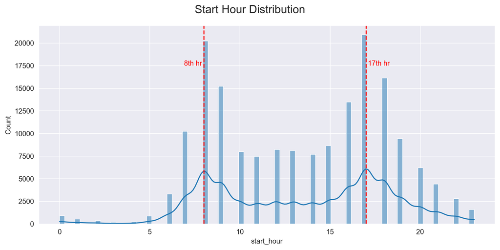

```python
# creating 1 figure and 1 subplot
fig, axes = plt.subplots(1,1, figsize=(10,5), dpi=250)
# assigning main title to figure
fig.suptitle("Start Hour Distribution", fontsize=16)
# histogram plot
sns.histplot(x='start_hour', data=df_clean, kde=True)
# marking red dotted line on 8th hour
axes.axvline(8, color="red", linestyle="--")
# commenting on 8th hour
axes.text(x=6.9, y=17500, s="8th hr", color="red")
# marking red dotted line on 17th hour
axes.axvline(17, color="red", linestyle="--")
# commenting on 17th hour
axes.text(x=17.1, y=17500, s="17th hr", color="red")
# adjust the layout to use the least amount of space
plt.tight_layout()
plt.savefig('images/start_hr_dist.png');
```

- There are 2 peaks in the 'start_hour' column, i.e., around the 8th and the 17th hour there are more number of trips. So, the morning around 8 am and the evening around 5 pm are the two busiest start times, which may indicated that these are the office start and end times.

**2) Distribution of `end_hour`**

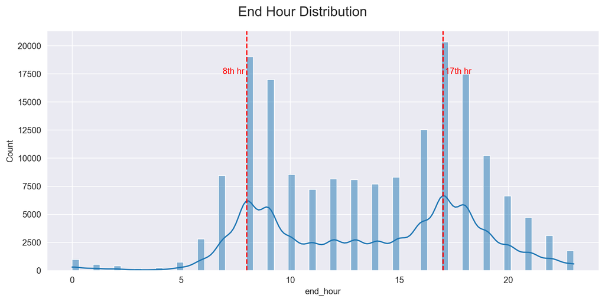

```python
# creating 1 figure and 1 axes subplot
fig, axes = plt.subplots(1,1, figsize=(10,5), dpi=250)
# assigning main title to figure
fig.suptitle("End Hour Distribution", fontsize=16)
# histogram plot
sns.histplot(x='end_hour', data=df_clean, kde=True)
# marking red dotted line on 8th hour
axes.axvline(8, color="red", linestyle="--")
# commenting on 8th hour
axes.text(x=6.9, y=17500, s="8th hr", color="red")
# marking red dotted line on 17th hour
axes.axvline(17, color="red", linestyle="--")
# commenting on 17th hour
axes.text(x=17.1, y=17500, s="17th hr", color="red")
# adjust the layout to use the least amount of space
plt.tight_layout()
plt.savefig('images/end_hr_dist.png');
```

- The end hour peak points look similar to that of start hour, hence indicating the fact that these must be office hours which are causing the busy peak hours.

**3) Distribution of `start_day_of_week` & `end_day_of_week`**

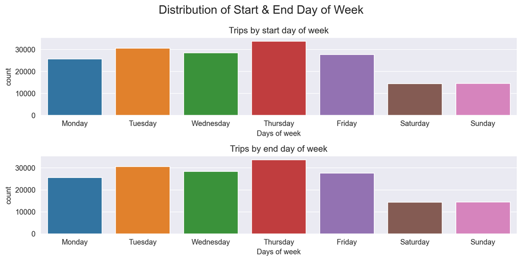

```python
# creating a 'week' list to store name of weeks in order
week = ['Monday', 'Tuesday', 'Wednesday', 'Thursday', 'Friday', 'Saturday', 'Sunday']
# creating a figure and 2 subplot
fig, axes = plt.subplots(2,1, figsize=(10,5), dpi=250)

fig.suptitle('Distribution of Start & End Day of Week', fontsize=16)
# using seaborn to create a countplot on first axes
sns.countplot(x="start_day_of_week", data=df_clean, order=week, ax=axes[0])
# setting title on first subplot
axes[0].set_title("Trips by start day of week")
# setting xlabel on first subplot
axes[0].set_xlabel("Days of week")

sns.countplot(x="end_day_of_week", data=df_clean, order=week, ax=axes[1])
axes[1].set_title("Trips by end day of week")
axes[1].set_xlabel("Days of week")

plt.tight_layout()
plt.savefig('images/start_end_day_of_week_dist.png');
```

- Thursday seems to be the day of week which has the most number of trips, followed by Tuesday and Wednesday.
- During weekends/offdays the number of trips are almost half of that during working day.

**4) Trip duration Distribution**

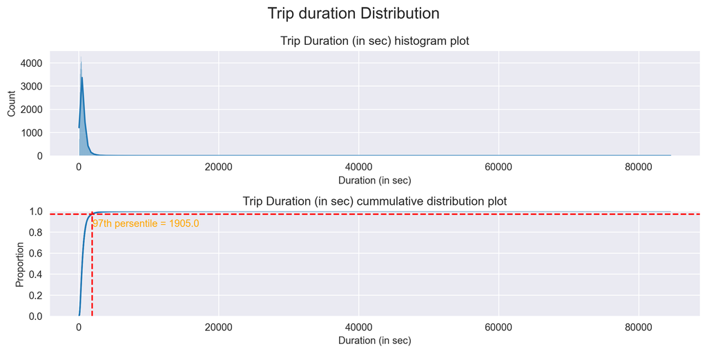

```python
# creating 2 subplots axes[0], axes[1]
fig, axes = plt.subplots(2,1, figsize=(10,5), dpi=250)
# main title
fig.suptitle('Trip duration Distribution', fontsize=16)
# histogram plot
sns.histplot(x='duration_sec', data=df_clean, kde=True, ax=axes[0])
# ecdf plot
sns.ecdfplot(x='duration_sec', data=df_clean, ax=axes[1])
# ecdf customization
x_value = axes[1].lines[0].get_xdata()[np.where(axes[1].lines[0].get_ydata() >= 0.97)][0]
axes[1].axhline(0.97, color="red", linestyle="--")
axes[1].axvline(x_value, color="red", linestyle="--")
axes[1].text(x=x_value+100, y=0.85, s=f"97th persentile = {x_value}", color="orange")
# titles and labels
axes[0].set_title("Trip Duration (in sec) histogram plot")
axes[1].set_title("Trip Duration (in sec) cummulative distribution plot")
axes[0].set_xlabel("Duration (in sec)")
axes[1].set_xlabel("Duration (in sec)")

plt.tight_layout()
plt.savefig("images/trip_duration_sec_dist.png");
```

- from the above histogram plot, it is seen that 'duration_sec' is right skewed.
- from the ecdf plot, it is seen that 97% of the trips are shorter than 1905 sec or 31.75 mins

**5) Distribution of Trip Duration & its mean**

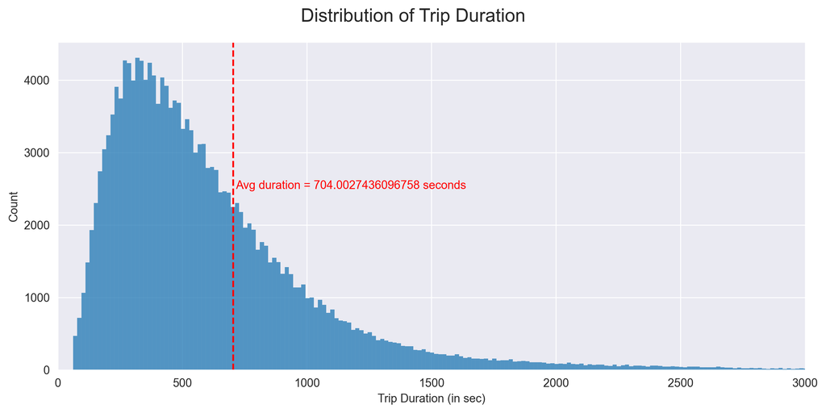

```python
# calculating mean of 'duration_sec'
td_avg = np.mean(df_clean.duration_sec)

fig, axes = plt.subplots(1,1, figsize=(10,5), dpi=250)

fig.suptitle("Distribution of Trip Duration", fontsize=16)

sns.histplot(x='duration_sec', data=df_clean)
# limiting the x axis withing the specified ticks
axes.set_xlim(0,3000)
# marking the mean with red dotted line
axes.axvline(td_avg, color="red", linestyle="--")
# commenting the mean value
axes.text(x=td_avg+10, y=2500, s=f"Avg duration = {td_avg} seconds", color="red")

axes.set_xlabel("Trip Duration (in sec)")

plt.tight_layout()
plt.savefig('images/mean_&_trip_duration_dist.png');
```

- average trip duration is 704 secs or 11.7 minutes.

**6) Distribution of `user_type`, `member_gender`, `bike_share_for_all_trip`**

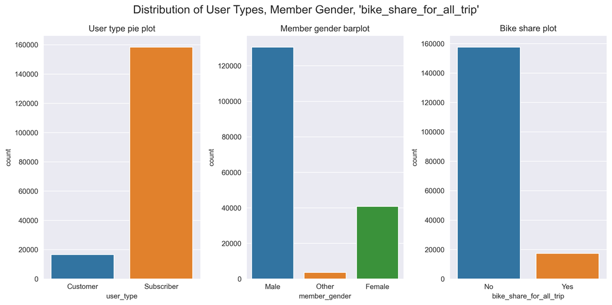

```python
# creating 3 subplots
fig, axes = plt.subplots(1, 3, figsize=(12,6), dpi=300)

fig.suptitle("Distribution of User Types, Member Gender, 'bike_share_for_all_trip'", fontsize=16)

sns.countplot(x="user_type", data=df_clean, ax=axes[0])

axes[0].set_title("User type pie plot")

sns.countplot(x="member_gender", data=df_clean, ax=axes[1])

axes[1].set_title("Member gender barplot")

sns.countplot(x="bike_share_for_all_trip", data=df_clean, ax=axes[2])

axes[2].set_title("Bike share plot")

plt.tight_layout()
plt.savefig('images/usertype_gender_bikeshare_dist.png');
```

- We can clearly see that Subscribers are significantly higher than customers in usage.
- Males are higher than Females followed by other gender.
- Users who do bike share are significantly lower than who don't do bike share.

### Discuss the distribution(s) of your variable(s) of interest. Were there any unusual points? Did you need to perform any transformations?

- It is seen that 'duration_sec' is right skewed.
- 97% of the trips are shorter than 1905 sec or 31.75 mins
- There are 2 peaks in the 'start_hour' column, i.e., around the 8th and the 17th hour there are more number of trips. So, the morning around 8 am and the evening around 5 pm are the two busiest start times, which may indicated that these are the office start and end times.
- The end hour peak points look similar to that of start hour, hence indicating the fact that these must be office hours which are causing the busy peak hours.
- Thursday seems to be the day of week which has the most number of trips, followed by Tuesday and Wednesday.
- During weekends/offdays the number of trips are almost half of that during working day.
- Average trip duration is 704 secs or 11.7 minutes.
- We can clearly see that Subscribers are significantly using bikes in higher numbers than customers in usage.
- Males are higher than Females followed by other gender.
- Users who do bike share are significantly lower than who don't do bike share.

### Of the features you investigated, were there any unusual distributions? Did you perform any operations on the data to tidy, adjust, or change the form of the data? If so, why did you do this?

- All the null values were removed in order to plot distribution of only those records which were complete.
- Datatypes of some columns were changed in order to facilitate proper analysis.
- Some new columns were created like `start_hour`, `start_day_of_week`, etc.

## Bivariate Exploration

converting `start_day_of_week` columns to categorical column

```python
# converting "start_day_of_week" to categorical type
df_clean["start_day_of_week"] = df_clean["start_day_of_week"].astype("category")
# setting the order
df_clean["start_day_of_week"] = df_clean["start_day_of_week"].cat.set_categories(['Monday', 'Tuesday', 'Wednesday', 'Thursday', 'Friday', 'Saturday', 'Sunday'], ordered=True)
```

**1) Plot of User Type, Gender, Day of Week & Bikeshare status vs Duration of Trip**

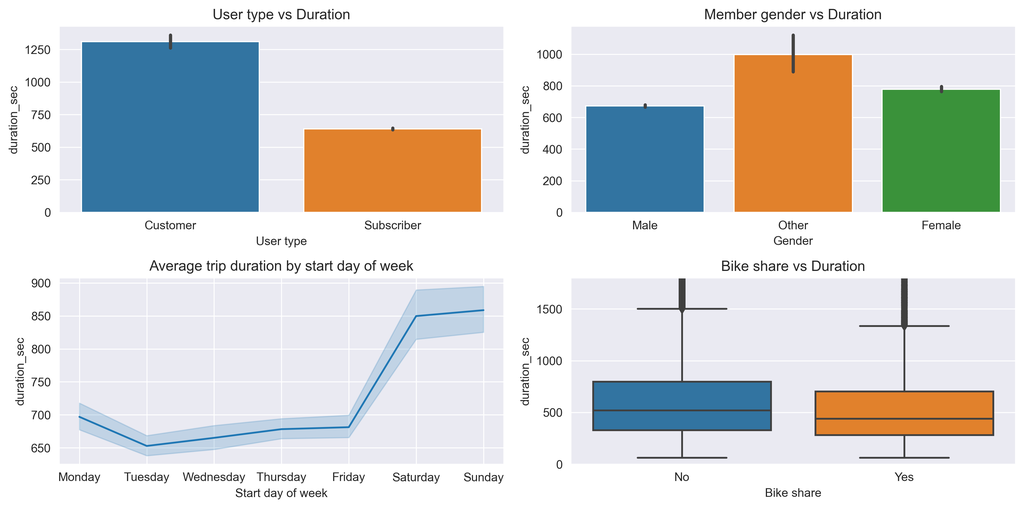

```python
fig, axes = plt.subplots(2, 2, figsize=(12,6), dpi=300)

sns.barplot(x="user_type", y="duration_sec", data=df_clean, ax=axes[0,0])

axes[0,0].set_title("User type vs Duration")
axes[0,0].set_xlabel("User type")

sns.barplot(x="member_gender", y="duration_sec", data=df_clean, ax=axes[0,1])

axes[0,1].set_title("Member gender vs Duration")
axes[0,1].set_xlabel("Gender")

sns.lineplot(x="start_day_of_week", y="duration_sec", data=df_clean, estimator="mean", ax=axes[1,0])

axes[1,0].set_title("Average trip duration by start day of week")
axes[1,0].set_xlabel("Start day of week")

sns.boxplot(x="bike_share_for_all_trip", y="duration_sec", data=df_clean, ax=axes[1,1])

axes[1,1].set_ylim(0,1800)
axes[1,1].set_title("Bike share vs Duration")
axes[1,1].set_xlabel("Bike share")

plt.tight_layout()
plt.savefig('images/usertype_gender_startday_ofweek_bikeshare_vs_trip_duration.png');
```

**2) Start Hour and End Hour vs Duration(in sec)**

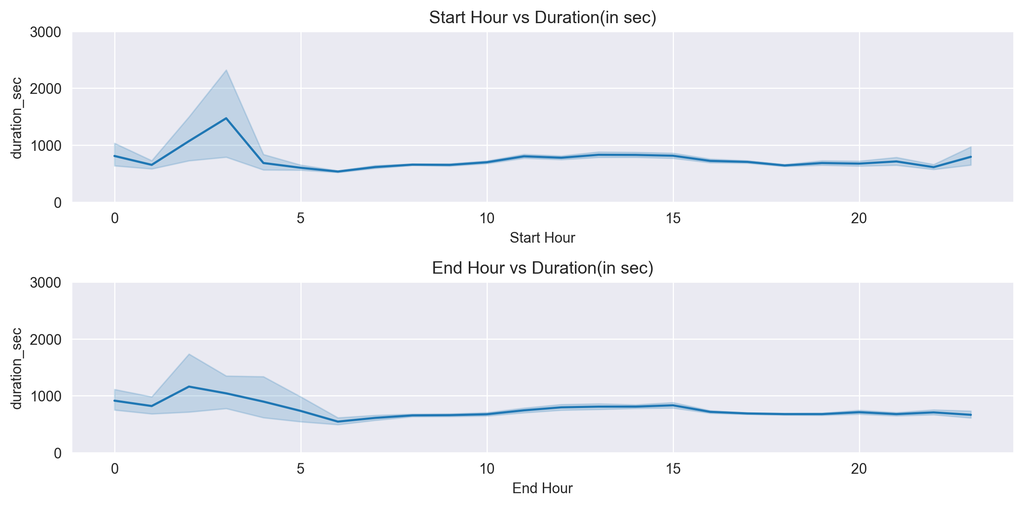

```python
fig, axes = plt.subplots(2,1, figsize=(10,5), dpi=250)

sns.lineplot(x="start_hour", y='duration_sec', data=df_clean, ax=axes[0])
axes[0].set_ylim(0,3000)
axes[0].set_title("Start Hour vs Duration(in sec)")
axes[0].set_xlabel("Start Hour")

sns.lineplot(x="end_hour", y='duration_sec', data=df_clean, ax=axes[1])
axes[1].set_ylim(0,3000)
axes[1].set_title("End Hour vs Duration(in sec)")
axes[1].set_xlabel("End Hour")

plt.tight_layout()
plt.savefig('images/starthr_&_endhr_vs_duration.png');
```

- It seems that longer durations trips occur after midnight (0th hour/12am) and before morning (around 4:30/5am).

### Did you observe any interesting relationships between the other features (not the main feature(s) of interest)?

- Yes, between bike share users and trip duration.
- Also, while Males are dominating user gender, they are not the users which travel more duration, infact they are travel least duration.

## Multivariate Exploration

creating morning, afternoon, evening and night time of the day column

```python
# defining the time of the day function
def timeofday(time):
    if time >= 6 and time < 12:
        return "Morning"
    elif time >=12 and time < 16:
        return "Afternoon"
    elif time >=16 and time < 19:
        return "Evening"
    else:
        return "Night"
```

```python
# creating the time of day column
df_clean["time_of_day"] = df_clean.start_hour.apply(timeofday)
```

**1) Time of day vs Trip Duration grouped by Member Gender**

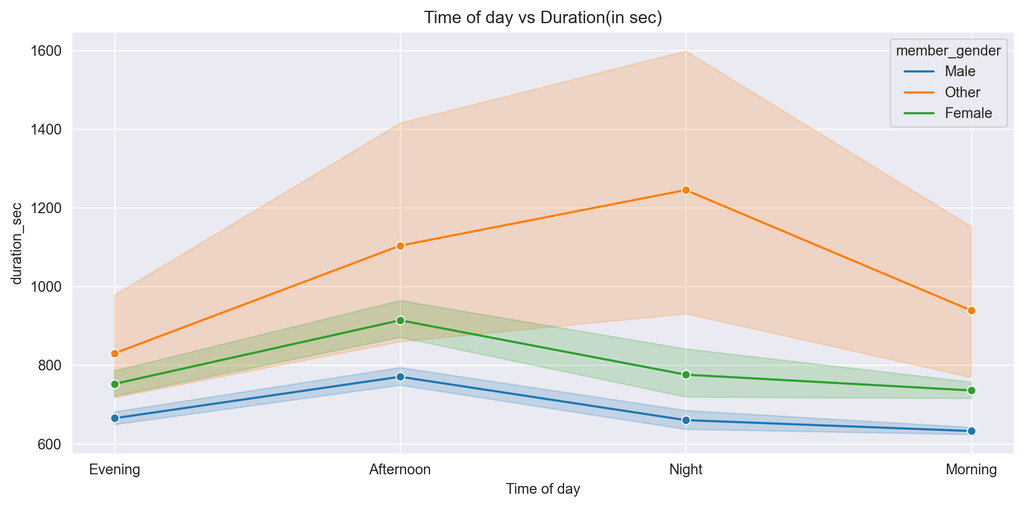

```python
fig, axes = plt.subplots(1,1, figsize=(10,5), dpi=250)

sns.lineplot(x="time_of_day", y='duration_sec', hue='member_gender', marker='o', data=df_clean)

axes.set_title("Time of day vs Duration(in sec)")
axes.set_xlabel("Time of day")

plt.tight_layout()
plt.savefig('images/timeofday_vs_duration_by_gender.png');
```

- The 'Other' gender uses the bike for longer duration as opposed to Male & Female gender.

**2) Lineplot for Time of Day vs Trip Duration grouped by Gender & Days in a week**

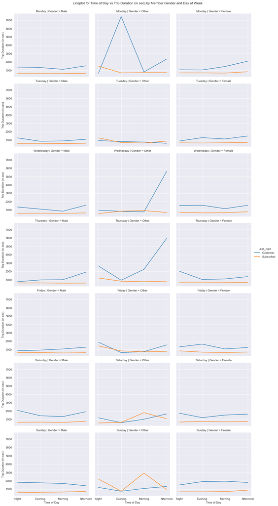

```python
# creating a facet grid to show same plot for different subsets of the data
# assigning col and row argument to create different subplots and hue to create a 3rd variable
# assigning height and aspect appropriately
g = sns.FacetGrid(df_clean, col='member_gender', row='start_day_of_week', hue='user_type', height=3.5, aspect=1.2)
# inputting a datafram and getting a dataframe as a facetgrid by using g.map_dataframe
g.map_dataframe(sns.lineplot, x="time_of_day", y="duration_sec", ci=None)

g.fig.suptitle("Lineplot for Time of Day vs Trip Duration (in sec) by Member Gender and Day of Week", y=1.01)

g.add_legend()

g.set_axis_labels("Time of Day", "Trip Duration (in sec)")

g.set_titles(col_template='Gender = {col_name}', row_template='{row_name}')

plt.savefig('images/timeofday_vs_duration_by_gender_&_dayname.png');
```

- The 'Other' gender takes longer duration on Monday, Wednesday & Thursday.

**2) Lineplot for Time of Day vs Trip Duration grouped by Gender & Bike share status**

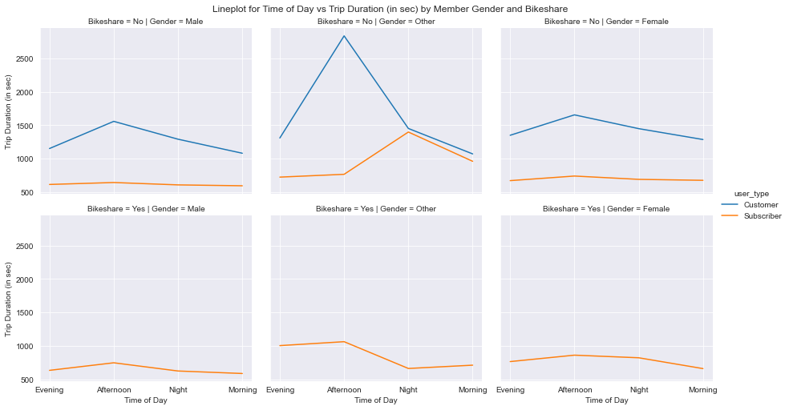

```python
g = sns.FacetGrid(df_clean, col='member_gender', row='bike_share_for_all_trip', hue='user_type', height=3.5, aspect=1.2)
g.map_dataframe(sns.lineplot, x="time_of_day", y="duration_sec", ci=None)
g.fig.suptitle("Lineplot for Time of Day vs Trip Duration (in sec) by Member Gender and Bikeshare", y=1.01)
g.add_legend()
g.set_axis_labels("Time of Day", "Trip Duration (in sec)")
g.set_titles(col_template='Gender = {col_name}', row_template='Bikeshare = {row_name}')
plt.savefig('images/timeofday_vs_duration_by_gender_&_bikeshare.png');
```

- The 'Other' gender which doesn't share bike goes for longer duration are all Customers.

**3) Average trip duration by start day of week for different user types**

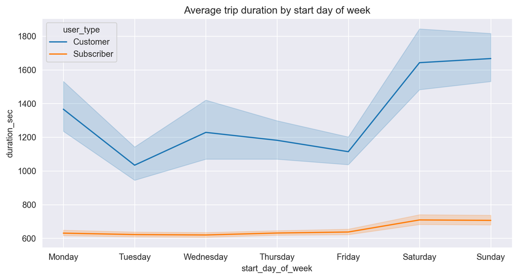

```python
fig, axes = plt.subplots(1,1, figsize=(10,5), dpi=250)
sns.lineplot(x="start_day_of_week", y="duration_sec", hue='user_type', data=df_clean, estimator="mean", ax=axes)
axes.set_title("Average trip duration by start day of week")
plt.savefig('images/avgduration_vs_dayname_by_usertype.png');
```

- The above fig shows that on average no Subscriber has taken longer duration trips than Customers.

### Talk about some of the relationships you observed in this part of the investigation. Were there features that strengthened each other in terms of looking at your feature(s) of interest?

- The 'Other' gender uses the bike for longer duration as opposed to Male & Female gender.
- The 'Other' gender takes longer duration on Monday, Wednesday & Thursday.
- The 'Other' gender which doesn't share bike goes for longer duration are all Customers.
- On average no Subscriber has taken longer duration trips than Customers.

### Were there any interesting or surprising interactions between features?

- No customers did bike share. Only subscribers did bikeshare

## Conclusions

While doing the above:-

- All the null values were removed in order to plot distribution of only those records which were complete.
- Datatypes of some columns were changed in order to facilitate proper analysis.
- Some new columns were created like start_hour, start_day_of_week, etc.

## Further Research scope

Further research can be done by:-

- Calculating age of the users and exploring its feature against other features to get more insights into users of different age groups.
- Distance can be calculated from the latitude and longitude and further relations between the station and time taken and speed could be found out to dig deeper into user behaviours.